# Exploring quantitative traits in a mouse population

Practical 1: Variation, association and family structure

## Learning objectives

After this practical you should be able to describe a quantitative trait using means, variances and distributions; distinguish phenotypic association from genetic correlation; explore sex, replicate and family patterns; and explain why these summaries do not estimate heritability.

You need introductory statistics and basic R. All calculations use base R; no additional analysis packages are required. Work through the questions before opening the suggested answers.

Read alongside the introductory slides on quantitative variation, the mean, variance and covariance and correlation.

## Biological question and data

How do body weight and blood glucose vary among mice, and how do those patterns relate to family, sex and experimental replicate?

The data describe an F2 population derived from M16 and ICR lines, with traits measured at eight weeks. The historical population description reports 1,181 mice; the teaching file contains 1,177 records. The file alone does not explain the difference, so we use its observed record count throughout.

| Variable | Meaning | R representation |
| --- | --- | --- |
| `BW` | Body weight | Numeric |
| `Gl` | Blood glucose measurement | Numeric |
| `sire`, `dam` | Father and mother labels | Factors |
| `sex` | Recorded sex | Factor |
| `reps` | Experimental replicate | Factor |

The RDS file does not include measurement-unit metadata. We therefore label axes in recorded units rather than infer units. Parent labels are identities, not numerical covariates. Row names are retained source labels; do not assume they provide a complete pedigree or a validated identifier mapping.

### Load a reproducible data version

Download the public teaching file once into R’s temporary directory. The URL fixes a repository revision; the checksum checks that the bytes match the version used here. No raw data are changed or added to the course repository. Internet access is needed for the initial download.

**Show R code**

```r
revision <- "224a4024f558ff9c0a481468979178e33b81b27b"
data_url <- paste0("https://raw.githubusercontent.com/psoerensen/bgcourse/",
                   revision, "/data/mouse.rds")
data_file <- file.path(tempdir(), "qg1-mouse.rds")
if (!file.exists(data_file)) {
  download.file(data_url, data_file, mode = "wb", quiet = TRUE)
}
stopifnot(unname(tools::md5sum(data_file)) ==
            "115b9d800485bad86c253c8c6a7d770d")
mouse <- readRDS(data_file)
stopifnot(is.data.frame(mouse),
          identical(names(mouse), c("sire", "dam", "sex", "reps", "Gl", "BW")),
          is.numeric(mouse$BW), is.numeric(mouse$Gl))
str(mouse)
```

```
'data.frame':   1177 obs. of  6 variables:
 $ sire: Factor w/ 11 levels "25","28","34",..: 6 6 6 6 6 6 6 6 6 6 ...
 $ dam : Factor w/ 55 levels "26","27","29",..: 8 8 8 8 8 8 8 8 8 8 ...
 $ sex : Factor w/ 2 levels "Female","Male": 1 1 1 1 2 2 2 2 1 1 ...
 $ reps: Factor w/ 3 levels "1","2","3": 1 1 1 1 1 1 1 1 2 2 ...
 $ Gl  : num  187 136 115 125 112 190 169 159 111 89 ...
 $ BW  : num  36.6 33.3 42.1 37.1 38.4 ...
```

## 1. Inspect records and missingness

**Question 1.** How many records and variables are present? Are any values missing? Why should we check before calculating a mean?

**Show R code**

```r
c(records = nrow(mouse), variables = ncol(mouse))
```

```
  records variables
     1177         6
```

**Show R code**

```r
colSums(is.na(mouse))
```

```
sire  dam  sex reps   Gl   BW
   0    0    0    0    0    0
```

**Show R code**

```r
table(mouse$sex)
```

```
Female   Male
   589    588
```

**Show R code**

```r
table(mouse$reps)
```

```
  1   2   3
415 427 335
```

**Suggested answer**

There are 1177 records and 6 variables. This version has no missing values in these fields. Missing values in another dataset would require a declared exclusion or imputation policy and reported denominators. A missing phenotype is not a zero phenotype.

## 2. Describe quantitative variation

For observations $y_1,\ldots,y_n$, the sample mean is $\bar y=\sum_i y_i/n$ and the sample variance is

$$s_y^2=\frac{1}{n-1}\sum_{i=1}^n(y_i-\bar y)^2.$$

The standard deviation $s_y$ has the same units as the observations; variance has squared units. These describe the available phenotypes, combining genetic, environmental and other sources of variation.

**Question 2.** Calculate the mean, variance and standard deviation of each trait. Can their raw variances be compared as measures of genetic variability?

**Show R code**

```r
trait_summary <- t(vapply(mouse[c("BW", "Gl")], function(y) {
  c(n = sum(!is.na(y)), mean = mean(y), variance = var(y),
    sd = sd(y), minimum = min(y), maximum = max(y))
}, numeric(6)))
knitr::kable(trait_summary, digits = 3, caption = "Observed phenotype summaries")
```

Observed phenotype summaries

|  | n | mean | variance | sd | minimum | maximum |
| --- | --- | --- | --- | --- | --- | --- |
| BW | 1177 | 38.724 | 37.845 | 6.152 | 23.04 | 60.28 |
| Gl | 1177 | 144.223 | 1150.660 | 33.921 | 65.00 | 292.00 |

**Suggested answer**

Mean body weight is 38.724 and mean glucose is 144.223 in their recorded units. Raw variances depend on measurement scale, and neither variance is an estimate of additive genetic variance.

### Inspect the distributions

**Show R code**

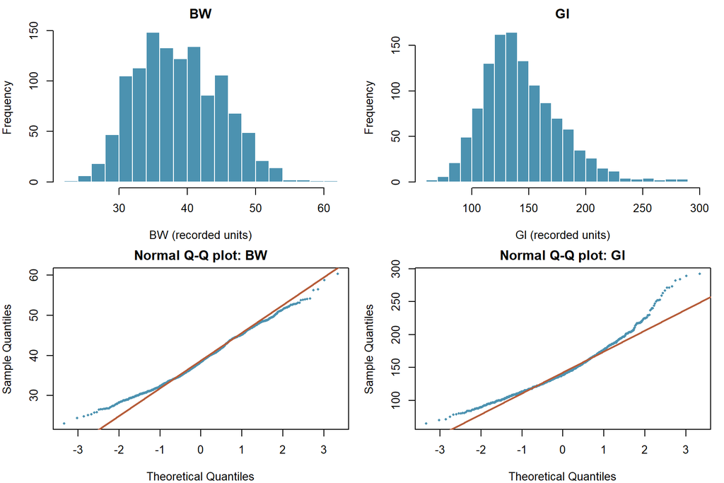

Figure 1: Distributions of body weight and glucose in the teaching sample.

```r
local({
  old <- par(mfrow = c(2, 2), mar = c(4, 4, 2, 1))
  on.exit(par(old))
  for (trait in c("BW", "Gl")) {
    hist(mouse[[trait]], breaks = 20, col = "#4C92B0", border = "white",
         main = trait, xlab = paste(trait, "(recorded units)"))
  }
  for (trait in c("BW", "Gl")) {
    qqnorm(mouse[[trait]], main = paste("Normal Q-Q plot:", trait), pch = 16,
           cex = 0.5, col = "#4C92B0")
    qqline(mouse[[trait]], col = "#B65C39", lwd = 2)
  }
})
```

**Question 3.** Which trait has the more pronounced upper tail? Do the plots justify saying that all observations are normally distributed?

**Suggested answer**

Inspect departures from the Q-Q reference line, particularly in the tails. Glucose has a relatively pronounced upper tail. A roughly bell-shaped histogram does not prove normality. These are marginal phenotype distributions; a later regression model makes assumptions about conditional residuals, and observations within families may be dependent.

## 3. Explore the relationship between traits

Sample covariance measures joint variation, while Pearson correlation rescales covariance:

$$r_{BW,Gl}=\frac{s_{BW,Gl}}{s_{BW}s_{Gl}}.$$

**Question 4.** Are heavier mice generally associated with higher glucose measurements? Does that association establish genetic correlation or causation?

**Show R code**

```
 covariance correlation
113.5316233   0.5440533
```

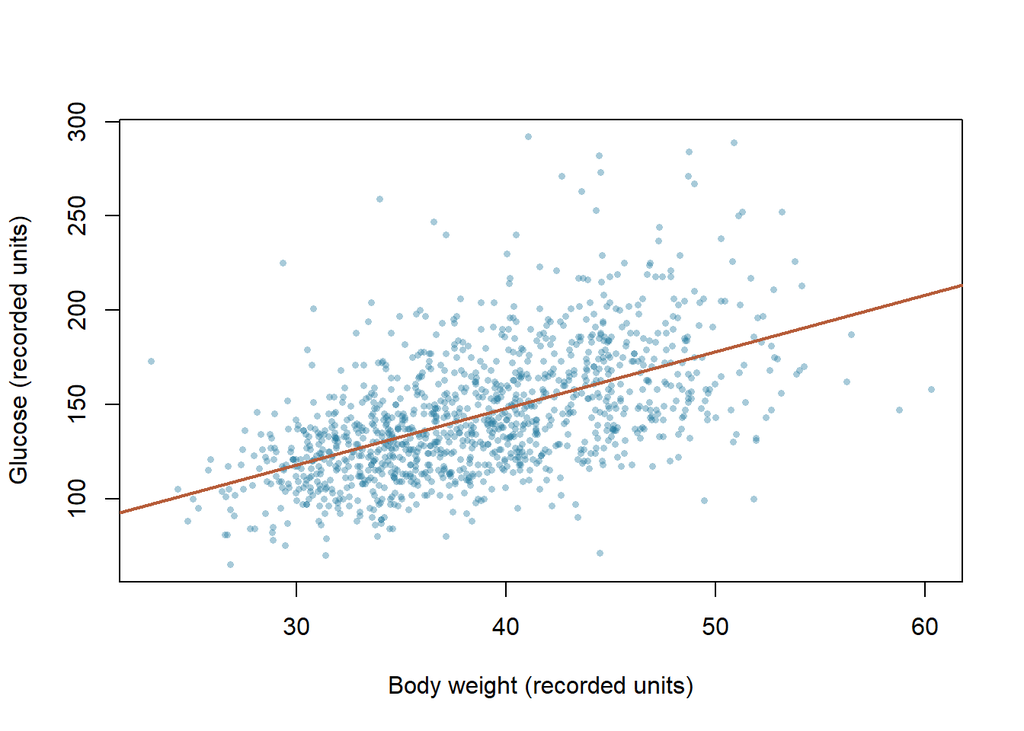

Figure 2: Phenotypic association between body weight and glucose; the line is a descriptive linear fit.

```r
plot(Gl ~ BW, data = mouse, pch = 16, cex = 0.6,
     col = adjustcolor("#247BA0", alpha.f = 0.4),
     xlab = "Body weight (recorded units)",
     ylab = "Glucose (recorded units)")
abline(lm(Gl ~ BW, data = mouse), col = "#B65C39", lwd = 2)
c(covariance = cov(mouse$BW, mouse$Gl),
  correlation = cor(mouse$BW, mouse$Gl))
```

**Suggested answer**

The observed correlation is 0.544, a positive phenotypic association. Shared environment, sex, family and other factors can contribute. Estimating genetic correlation requires a model separating genetic covariance from other covariance. A conventional independent-observation correlation test would also need its sampling assumptions reviewed for this family-structured sample.

## 4. Compare sex and replicate groups

**Question 5.** Compare group sizes, means and within-group spread. Does a difference between groups establish its biological cause?

**Show R code**

```r
aggregate(mouse[c("BW", "Gl")], mouse[c("sex")], mean)
```

```
     sex       BW       Gl
1 Female 34.54211 128.5739
2   Male 42.91285 159.8997
```

**Show R code**

```r
aggregate(mouse[c("BW", "Gl")], mouse[c("reps")], mean)
```

```
  reps       BW       Gl
1    1 37.97682 153.8506
2    2 37.69639 133.9836
3    3 40.95915 145.3493
```

**Show R code**

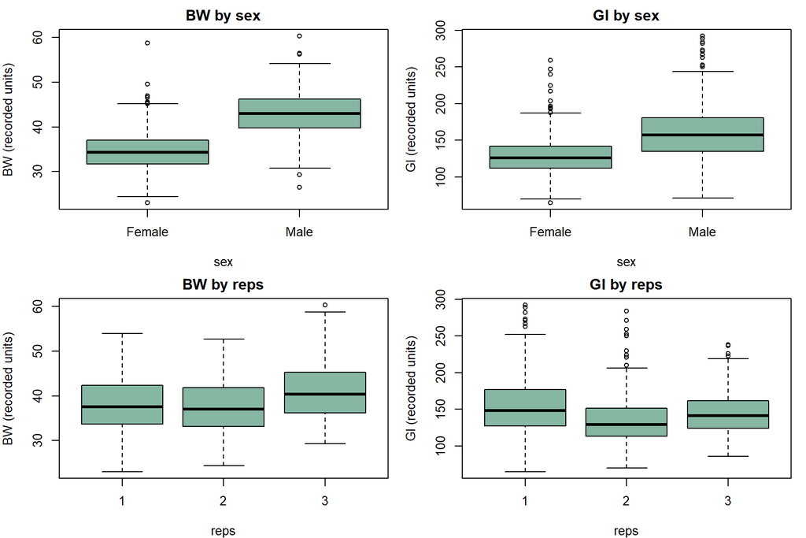

Figure 3: Trait distributions by recorded sex and experimental replicate.

```r
local({
  old <- par(mfrow = c(2, 2), mar = c(4, 4, 2, 1))
  on.exit(par(old))
  for (group in c("sex", "reps")) {
    for (trait in c("BW", "Gl")) {
      boxplot(reformulate(group, response = trait), data = mouse,
              col = "#86B7A3", main = paste(trait, "by", group),
              ylab = paste(trait, "(recorded units)"))
    }
  }
})
```

**Suggested answer**

Describe the direction, size and overlap of the plotted differences. Groups may differ in composition as well as environment; these comparisons are descriptive and do not identify causal effects. A later model should consider sex, replicate and the sampling design together.

## 5. Examine family structure

Related mice share some inherited variation, but family membership may also capture shared environment. Paternal and maternal families are different groupings; a sire can have offspring from several dams.

**Question 6.** How many sire and dam families are represented? Are their sizes balanced? Does a family pattern directly estimate heritability?

**Show R code**

```r
family_sizes <- list(sire = table(mouse$sire), dam = table(mouse$dam))
t(vapply(family_sizes, function(n) {
  c(families = length(n), minimum = min(n), maximum = max(n))
}, numeric(3)))
```

```
     families minimum maximum
sire       11      74     119
dam        55      15      24
```

**Show R code**

```r
# How many sire labels occur within each dam's records?
table(vapply(split(as.character(mouse$sire), mouse$dam),
             function(x) length(unique(x)), integer(1)))
```

```
 1
55
```

**Show R code**

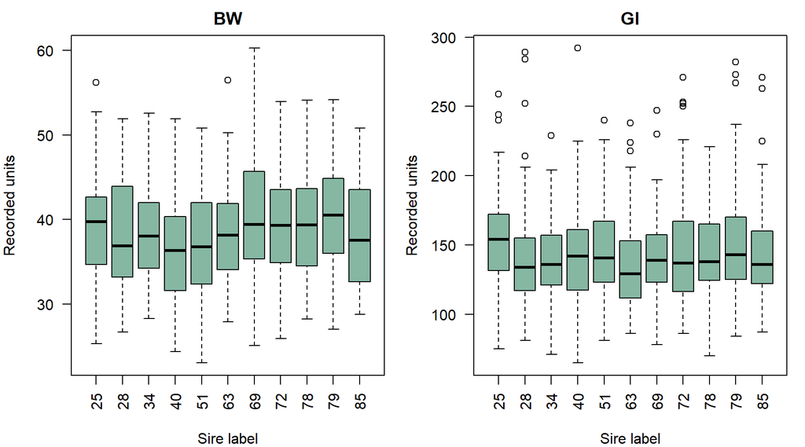

Figure 4: Phenotype distributions within paternal families. Differences can reflect inherited and environmental sources.

```r
local({
  old <- par(mfrow = c(1, 2), mar = c(4, 4, 2, 1))
  on.exit(par(old))
  for (trait in c("BW", "Gl")) {
    boxplot(reformulate("sire", response = trait), data = mouse,
            col = "#86B7A3", main = trait, xlab = "Sire label",
            ylab = "Recorded units", las = 2)
  }
})
```

**Suggested answer**

There are 11 sire families and 55 dam families. Their sizes range from 74 to 119 and from 15 to 24, respectively. Family contrasts alone do not separate additive genetic, maternal and shared environmental effects. Later practicals introduce pedigree relationships and variance-component models.

## 6. Move from exploration to modelling

An exploratory regression can compare sex and replicate patterns while keeping family modelling for a later practical. For body weight, write

$$BW_i=\mu+\beta_{sex(i)}+\gamma_{rep(i)}+e_i.$$

Here $\mu$ is a reference-group mean, the coefficients express group contrasts, and $e_i$ is the residual. This model does not include genetic effects or account for within-family dependence.

**Show R code**

```r
fit <- lm(BW ~ sex + reps, data = mouse)
round(coef(fit), 3)
```

```
(Intercept)     sexMale       reps2       reps3
     33.899       8.337      -0.381       2.805
```

**Show R code**

```r
c(observed_variance = var(mouse$BW),
  residual_variance = var(residuals(fit)))
```

```
observed_variance residual_variance
         37.84458          18.45532
```

**Question 7.** Why is the residual variance not automatically environmental variance? Why should we avoid interpreting regression significance as a heritability estimate?

**Suggested answer**

Residuals contain all variation not described by these predictors, including unmodelled genetic and environmental sources. Heritability requires a defined population, variance decomposition and appropriate relationship/sampling model. Coefficient p-values from this simple model would rely on error assumptions that do not address family dependence.

## Exercises

1. Multiply body weight by 1,000. Predict the changes in its mean, variance, standard deviation and correlation with glucose, then verify them in R.
2. Calculate the body-weight/glucose correlation separately within each sex. Explain why these may differ from the pooled correlation.
3. Plot body weight by dam. Compare readability and family sizes with the sire plot.
4. Compare the unweighted mean of sire-family means with the overall mean. Explain the role of unequal family size.

### Suggested solutions

**Open exercise solutions**

**Show R code**

```r
scaled <- mouse$BW * 1000
c(mean_ratio = mean(scaled) / mean(mouse$BW),
  variance_ratio = var(scaled) / var(mouse$BW),
  sd_ratio = sd(scaled) / sd(mouse$BW),
  correlation = cor(scaled, mouse$Gl))
```

```
    mean_ratio variance_ratio       sd_ratio    correlation
  1.000000e+03   1.000000e+06   1.000000e+03   5.440533e-01
```

**Show R code**

```r
vapply(split(mouse, mouse$sex), function(d) cor(d$BW, d$Gl), numeric(1))
```

```
   Female      Male
0.3187436 0.3767951
```

**Show R code**

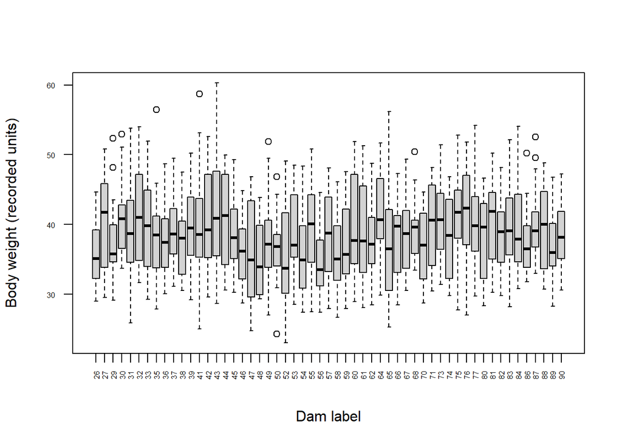

```r
boxplot(BW ~ dam, data = mouse, las = 2, cex.axis = 0.5,
        xlab = "Dam label", ylab = "Body weight (recorded units)")
```

**Show R code**

```r
sire_means <- tapply(mouse$BW, mouse$sire, mean)
c(overall = mean(mouse$BW), unweighted_family_mean = mean(sire_means),
  weighted_family_mean = weighted.mean(sire_means, table(mouse$sire)))
```

```
               overall unweighted_family_mean   weighted_family_mean
              38.72392               38.66481               38.72392
```

The mean and standard deviation multiply by 1,000; variance multiplies by 1,000,000; correlation is unchanged. Within-sex correlations describe different subsets and exclude between-sex mean differences. More dam families make their plot denser. Weighting family means by family size recovers the overall mean; equal weighting answers a different question.

## Connection to the next practical

Next we connect allele frequencies and genotype effects to quantitative variation, then distinguish genetic variance from phenotypic variance. `gpop` can support population summaries as its scientific interfaces become available; `gsim` provides simulated biological data where truth is known; `gsel` concerns selection objectives and decisions. None is required for this first descriptive practical, and model fitting remains with estimation tools.